# Model Fitting Process - November 14

Chaeyoung, Hong Gi, Gloria, John, James

December 14, 2022

```r
churchData <- read_csv('data/data.csv')
write_csv(churchData, 'data/data.csv')

Church <-read_survey('data/data.csv', legacy = TRUE)
```

```r
Church <- Church |>
  select(Weeks_Closed, Social_Distancing, Specific_denom,
         Livestreaming, Regions, Signage_of_protocols, Over65_Props) %>%
  na.omit()

summary(Church)
```

```
##   Weeks_Closed   Social_Distancing Specific_denom     Livestreaming
##  Min.   : 0.00   Mode :logical     Length:701         Mode :logical
##  1st Qu.: 8.00   FALSE:106         Class :character   FALSE:402
##  Median :13.00   TRUE :595         Mode  :character   TRUE :299
##  Mean   :20.87
##  3rd Qu.:28.00
##  Max.   :85.00
##    Regions          Signage_of_protocols  Over65_Props
##  Length:701         Mode :logical        Min.   :1.000
##  Class :character   FALSE:249            1st Qu.:3.000
##  Mode  :character   TRUE :452            Median :4.000
##                                          Mean   :4.693
##                                          3rd Qu.:7.000
##                                          Max.   :9.000
```

## Process Plan

#### Causal Diagram (copy and paste git hub link below to get image )

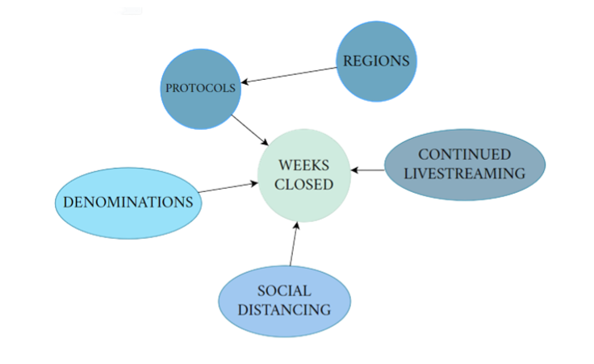

```r
knitr::include_graphics("https://github.com/jmw-75/photo-uploads/raw/main/img245.jpg")
```

**Response Variable**: Weeks Closed

**Predictors**: Specific denomination, Vaccination, Protocols, Region, Small Groups, Social Distancing, livestreaming, In person attendees

Notes: We were considering these predictors but we had some concerns and had to ask our partner for it. Revisions: We asked our partner about these variables and was told to not include them.

Our planning process started with evaluating the variables that are available in our data. We took in to our consideration of how big our data which is 767 rows and 151 columns and consider the possible predictors to use and the ones we have to exclude.

```r
model_church <- glmmTMB(Weeks_Closed ~ Social_Distancing
                        + Specific_denom
                        + Livestreaming
                        + Regions * Signage_of_protocols,
                        data = Church,
                        family = nbinom1(link = "log"))

model_church2 <- glmmTMB(Weeks_Closed ~ Social_Distancing
                         + Specific_denom
                         + Livestreaming
                         + Regions * Signage_of_protocols,
                         data = Church,
                         family = nbinom2(link = "log"))


BIC(model_church, model_church2)
```

```
##               df      BIC
## model_church  34 5708.837
## model_church2 34 5707.581
```

```r
summary(model_church)
```

```
##  Family: nbinom1  ( log )
## Formula:
## Weeks_Closed ~ Social_Distancing + Specific_denom + Livestreaming +
##     Regions * Signage_of_protocols
## Data: Church
##
##      AIC      BIC   logLik deviance df.resid
##   5554.1   5708.8  -2743.0   5486.1      667
##
##
## Dispersion parameter for nbinom1 family (): 12.7
##
## Conditional model:
##                                      Estimate Std. Error z value Pr(>|z|)
## (Intercept)                         2.881e+00  4.929e-01   5.846 5.04e-09 ***
## Social_DistancingTRUE              -2.136e-01  8.073e-02  -2.646 0.008135 **
## Specific_denomANG                  -4.343e-01  4.888e-01  -0.888 0.374281
## Specific_denomB                    -3.559e-01  5.057e-01  -0.704 0.481580
## Specific_denomC                     1.505e-01  8.937e-01   0.168 0.866275
## Specific_denomCRC                   4.211e-02  4.818e-01   0.087 0.930345
## Specific_denomCRC RCA               2.509e-01  6.014e-01   0.417 0.676563
## Specific_denomDOC                   8.417e-01  5.525e-01   1.524 0.127623
## Specific_denomECC                   6.873e-01  7.779e-01   0.883 0.376983
## Specific_denomELCA                  4.219e-01  4.809e-01   0.877 0.380266
## Specific_denomEVP                  -2.894e-01  8.918e-01  -0.324 0.745584
## Specific_denomLMS                  -1.663e-01  6.415e-01  -0.259 0.795399
## Specific_denomND                   -1.379e-01  4.875e-01  -0.283 0.777324
## Specific_denomORC                  -6.100e-01  9.443e-01  -0.646 0.518268
## Specific_denomPCA                  -2.486e-01  4.849e-01  -0.513 0.608209
## Specific_denomPCUSA                 1.085e+00  6.510e-01   1.667 0.095425 .
## Specific_denomRCA                   8.528e-02  4.836e-01   0.176 0.860036
## Specific_denomSDA                  -1.677e+01  2.286e+03  -0.007 0.994146
## Specific_denomUMC                  -2.050e-01  7.005e-01  -0.293 0.769749
## Specific_denomWES                  -1.265e+00  1.060e+00  -1.193 0.232711
## Specific_denomX                     5.138e-01  6.804e-01   0.755 0.450099
## LivestreamingTRUE                   4.777e-02  5.690e-02   0.840 0.401142
## RegionsNE                           3.167e-01  1.533e-01   2.066 0.038848 *
## RegionsSE                          -1.523e-01  1.508e-01  -1.010 0.312484
## RegionsSW                          -2.920e-01  2.308e-01  -1.265 0.205987
## RegionsW                            5.736e-01  1.466e-01   3.912 9.14e-05 ***
## RegionsX                           -5.627e-01  5.159e-01  -1.091 0.275378
## Signage_of_protocolsTRUE            4.192e-01  1.082e-01   3.875 0.000107 ***
## RegionsNE:Signage_of_protocolsTRUE -2.896e-01  1.773e-01  -1.633 0.102418
## RegionsSE:Signage_of_protocolsTRUE  1.094e-01  1.705e-01   0.642 0.521052
## RegionsSW:Signage_of_protocolsTRUE -6.931e-03  2.879e-01  -0.024 0.980792
## RegionsW:Signage_of_protocolsTRUE  -5.530e-01  1.708e-01  -3.238 0.001204 **
## RegionsX:Signage_of_protocolsTRUE  -6.612e-02  4.946e-01  -0.134 0.893660
## ---
## Signif. codes:  0 '***' 0.001 '**' 0.01 '*' 0.05 '.' 0.1 ' ' 1
```

## Model Assessment

```r
Church <- Church |>
  select(Weeks_Closed, Social_Distancing, Specific_denom,
         Livestreaming, Regions, Signage_of_protocols, Over65_Props) %>%
  na.omit() |>
  mutate(preds = predict(model_church),
         resids = resid(model_church))
```

### Scaled Residuals

Based on this assessment, we can see that the model passed tests for log linearity and non-constant variance. There does not seem to be a explicit trend in the scaled residuals for linearity. Scaled residuals also appear to be uniform.

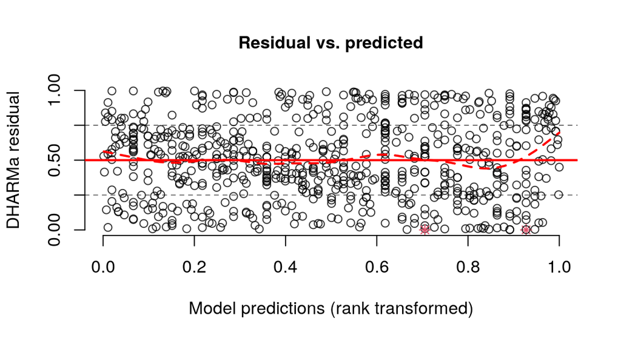

```r
nb_sim <- simulateResiduals(model_church)
plotResiduals(nb_sim,
              quantreg = FALSE)
```

### Independence

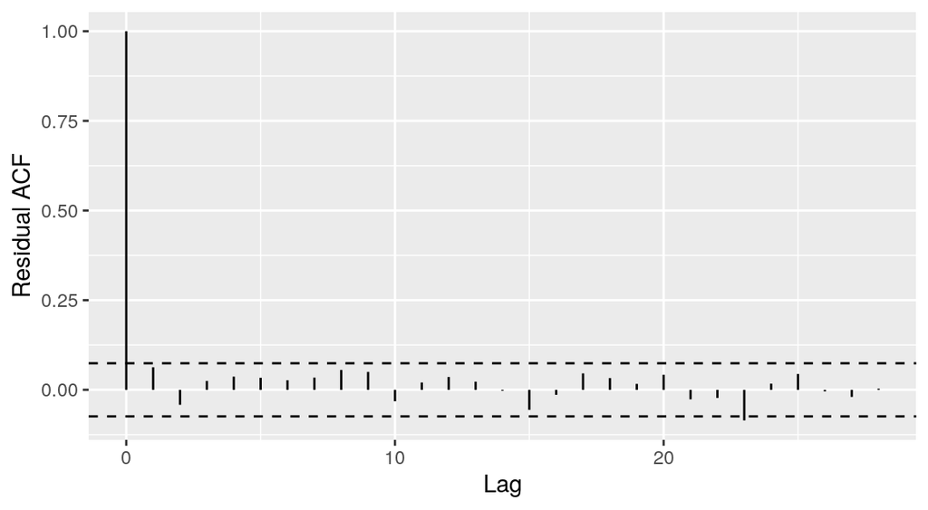

```r
gf_acf(~model_church)
```

## Model Selection (if needed)

Because of a large amount of rows, we opted to use BIC. The most optimal BIC value has a model with region and signage of protocols. Along with that, social distancing could be intepreted as a significant predictor, followed by specific denomination. However, when selecting the best model, it would be best to use Region and the Signage of protocols as a interacting effect for it.

```r
model_church <- model_church |>
  update(na.action = 'na.fail')
churchDataDredge <- dredge(model_church, rank = 'BIC')
churchDataDredge
```

```
## Global model call: glmmTMB(formula = Weeks_Closed ~ Social_Distancing + Specific_denom +
##     Livestreaming + Regions * Signage_of_protocols, data = Church,
##     family = nbinom1(link = "log"), ziformula = ~0, dispformula = ~1,
##     na.action = "na.fail")
## ---
## Model selection table
##    cnd((Int)) dsp((Int)) cnd(Lvs) cnd(Rgn) cnd(Sgn_of_prt) cnd(Scl_Dst)
## 7       2.872          +                 +               +
## 15      2.962          +                 +               +            +
## 8       2.869          +        +        +               +
## 5       2.752          +                                 +
## 16      2.958          +        +        +               +            +
## 21      2.872          +                                 +
## 29      2.984          +                                 +            +
## 6       2.737          +        +                        +
```

[output cut: 74 more lines]

## Prediction Plots

### Prediction Plot for Categorical - Categorical Interaction

```r
church_pred_data3 <- expand.grid(Specific_denom = 'ELCA',
                                Regions = c('MW', 'NE', 'SE', 'SW', 'W'),
                                Social_Distancing = TRUE,
                                Signage_of_protocols = c(FALSE,TRUE),
                                Livestreaming = TRUE,
                                Over65_Props = 2)|>
  mutate(Signage_of_protocols = factor(as.character(Signage_of_protocols)))
```

```r
church_preds <- predict(model_church,
                        newdata = church_pred_data3,
                        type = 'link',
                        se.fit = TRUE)
```

```r
church_pred_data3 <- church_pred_data3 |>
  mutate(c_pred = exp(church_preds$fit),
         ci_low = exp(church_preds$fit - 1.96*church_preds$se.fit),
         ci_up = exp(church_preds$fit + 1.96*church_preds$se.fit))
```

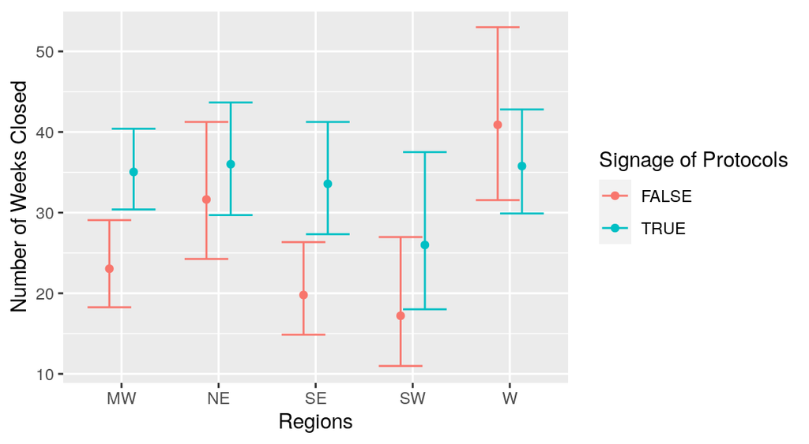

```r
gf_point(c_pred ~ Regions,
         color = ~Signage_of_protocols,
         position = position_dodge(0.5),
         data = church_pred_data3) |>
gf_errorbar(ci_low + ci_up ~ Regions,
            color = ~Signage_of_protocols,
            position = position_dodge(0.5)) |>
gf_labs(y = 'Number of Weeks Closed', color = "Signage of Protocols")
```

Region seems to be significant in predicting weeks closed. This is especially true when determining if the region resided in has COVID protocols signed or not. When unsigned, there is not as much overlap in the regions, indicating higher variance in weeks closed. When signed, one can see that the amount of weeks closed is on average higher than regions where protocols are not signed. This could indicate that as an interacting effect paired with regions is a significant predictor for weeks closed.

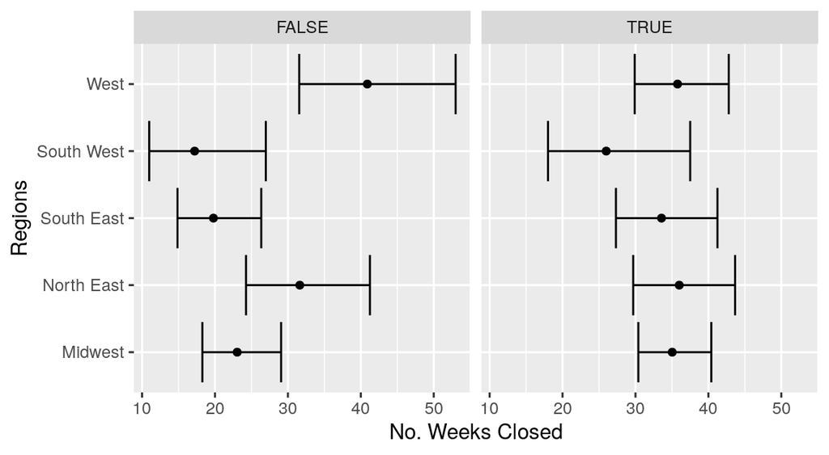

```r
gf_point(c_pred ~ Regions | Signage_of_protocols, data = church_pred_data3) |>
  gf_errorbar(ci_low + ci_up ~ Regions | Signage_of_protocols)|>
  gf_refine(scale_x_discrete(labels=c("Midwest", "North East", "South East", "South West", "West")), coord_flip()) |>
  gf_labs(y = 'No. Weeks Closed')
```

### Denomination Prediction Plot

```r
church_pred_data2 <- expand.grid(Specific_denom = c('PCA', 'CRC', 'ANG', 'B', 'ELCA', 'RCA'),
                                Regions = 'MW',
                                Social_Distancing = TRUE,
                                Signage_of_protocols = TRUE,
                                Livestreaming = TRUE)
```

```r
preds <- predict(model_church,
                 newdata = church_pred_data2,
                 se.fit = TRUE,
                 type = "link")
glimpse(preds)
```

```
## List of 2
##  $ fit   : Named num [1:6] 2.89 3.18 2.7 2.78 3.56 ...
##   ..- attr(*, "names")= chr [1:6] "eta_predict" "eta_predict" "eta_predict" "eta_predict" ...
##  $ se.fit: Named num [1:6] 0.0976 0.0793 0.1153 0.1736 0.0726 ...
##   ..- attr(*, "names")= chr [1:6] "eta_predict" "eta_predict" "eta_predict" "eta_predict" ...
```

```r
church_pred_data2 <- church_pred_data2 |>
  mutate(pred = preds$fit,
         pred.se = preds$se.fit,
         CI_lower = pred - 1.96*pred.se,
         CI_upper = pred + 1.96*pred.se)
```

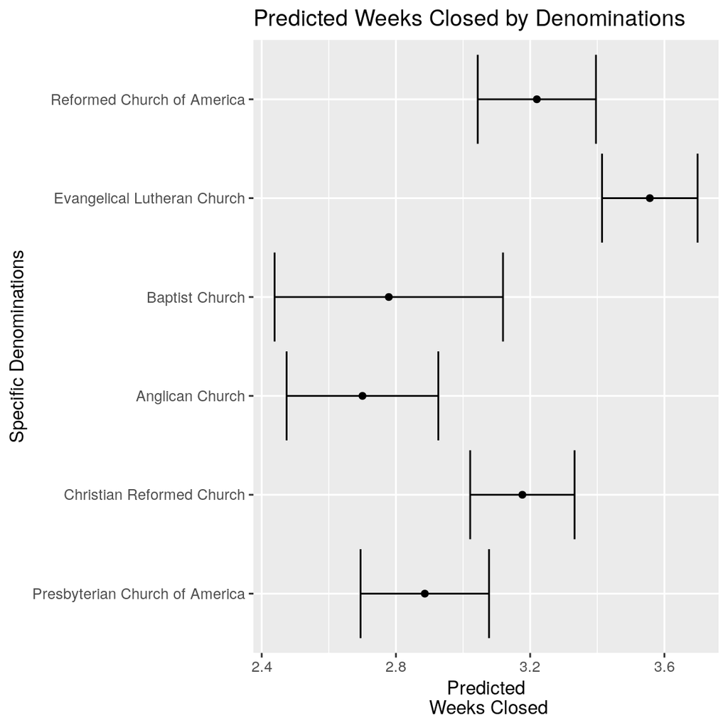

```r
gf_point(pred ~ Specific_denom,
         data = church_pred_data2) |>
  gf_labs(y = 'Predicted\n Weeks Closed',
          x = 'Specific Denominations',
          title = 'Predicted Weeks Closed by Denominations')|>
  gf_refine(scale_x_discrete(labels=c("Presbyterian Church of America", "Christian Reformed Church", "Anglican Church", "Baptist Church", "Evangelical Lutheran Church", "Reformed Church of America")), coord_flip())|>
  gf_errorbar(CI_lower + CI_upper ~ Specific_denom )
```

### Prediction Plot for Livestreaming

```r
church_pred_data4 <- expand.grid(Specific_denom = 'ELCA',
                                Regions = 'MW',
                                Social_Distancing = TRUE,
                                Signage_of_protocols = TRUE,
                                Livestreaming = c(TRUE, FALSE)) |>
  mutate(Signage_of_protocols = factor(as.character(Signage_of_protocols)))
```

```r
church_predsS <- predict(model_church,
                        newdata = church_pred_data4,
                        type = 'link',
                        se.fit = TRUE)
```

```r
church_pred_data4 <- church_pred_data4 |>
  mutate(l_pred = church_predsS$fit,
         l_pred.se = church_predsS$se.fit)
```

```r
church_pred_data4 <- church_pred_data4 |>
  mutate(l_pred = exp(church_predsS$fit),
         ci_low = exp(church_predsS$fit - 1.96*church_predsS$se.fit),
         ci_up = exp(church_predsS$fit + 1.96*church_predsS$se.fit))
```

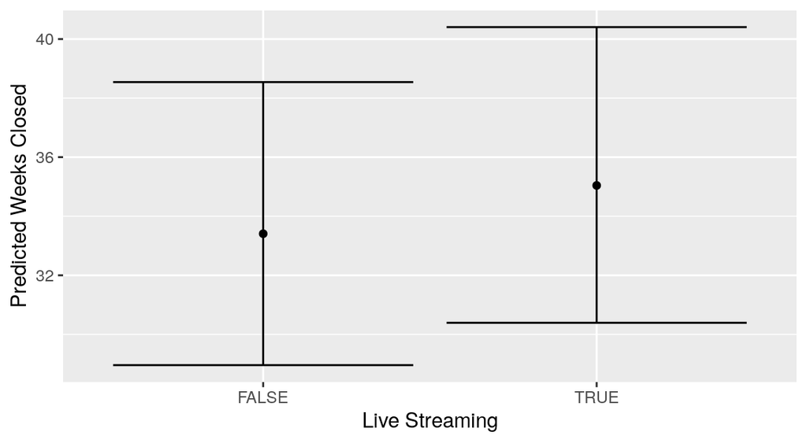

```r
gf_point(l_pred ~ Livestreaming, data = church_pred_data4) %>%
  gf_labs(x = "Live Streaming", y = "Predicted Weeks Closed")|>
  gf_errorbar(ci_low + ci_up ~ Livestreaming)
```

## Social distancing

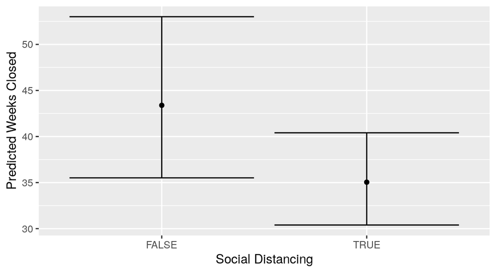

```r
church_pred_data6 <- expand.grid(Specific_denom = 'ELCA',
                                Regions = 'MW',
                                Social_Distancing = c(TRUE, FALSE),
                                Signage_of_protocols = TRUE,
                                Livestreaming = TRUE)



church_preds6 <- predict(model_church,
                        newdata = church_pred_data6,
                        type = 'link',
                        se.fit = TRUE)



church_pred_data6 <- church_pred_data6 |>
  mutate(l_pred = church_preds6$fit,
         l_pred.se = church_preds6$se.fit)



church_pred_data6 <- church_pred_data6 |>
  mutate(l_pred = exp(church_preds6$fit),
         ci_low1 = exp(church_preds6$fit - 1.96*church_preds6$se.fit),
         ci_up1 = exp(church_preds6$fit + 1.96*church_preds6$se.fit))



gf_point(l_pred ~ Social_Distancing, data = church_pred_data6) %>%
  gf_labs(x = "Social Distancing", y = "Predicted Weeks Closed")|>
  gf_errorbar(ci_low1 + ci_up1 ~ Social_Distancing)
```

Over 65 Proportion (asked by our partner)

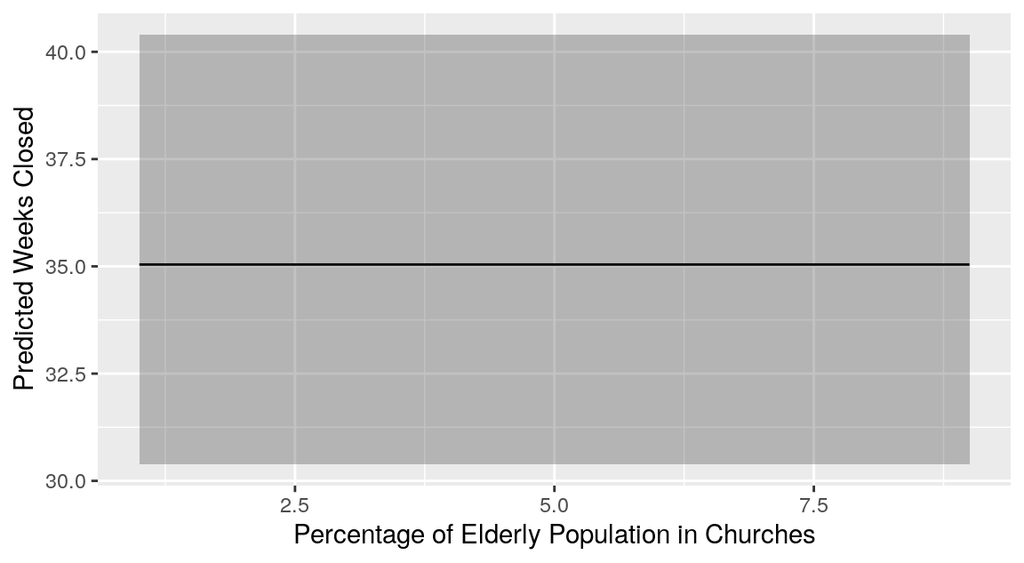

```r
church_pred_data5 <- expand.grid(Specific_denom = 'ELCA',
                                Regions = 'MW',
                                Social_Distancing = TRUE,
                                Signage_of_protocols = TRUE,
                                Livestreaming = TRUE,
                                Over65_Props = seq(from = 1,
                                                   by = 1,
                                                   to = 9))



church_preds5 <- predict(model_church,
                        newdata = church_pred_data5,
                        type = 'link',
                        se.fit = TRUE)


church_pred_data5 <- church_pred_data5 |>
  mutate(elderly_pred = church_preds5$fit,
         elderly_pred.se = church_preds5$se.fit)

church_pred_data5 <- church_pred_data5 |>
  mutate(elderly_pred = exp(church_preds5$fit),
         ci_low2 = exp(church_preds5$fit - 1.96*church_preds5$se.fit),
         ci_up2 = exp(church_preds5$fit + 1.96*church_preds5$se.fit))

gf_line(elderly_pred ~ Over65_Props, data = church_pred_data5) %>%
  gf_labs(x = "Percentage of Elderly Population in Churches", y = "Predicted Weeks Closed")|>
  gf_lims(x = c(1,9))|>
  gf_ribbon(ci_low2 + ci_up2 ~ Over65_Props)
```

# ELCA

Social Distancing differences between regions of ELCA churches (were asked by our partner to look at)

```r
elca_churches <- filter(Church, Specific_denom == "ELCA")

elca_churches %>%
  drop_na(Regions)
```

```
## # A tibble: 125 × 9
##    Weeks_Closed Social_Distancing Specific_denom Livestreaming Regions
##           <dbl> <lgl>             <chr>          <lgl>         <chr>
##  1           40 FALSE             ELCA           TRUE          MW
##  2           56 FALSE             ELCA           FALSE         MW
##  3           54 FALSE             ELCA           FALSE         W
##  4           68 TRUE              ELCA           FALSE         W
##  5           23 TRUE              ELCA           TRUE          MW
##  6           10 TRUE              ELCA           FALSE         MW
##  7           11 TRUE              ELCA           FALSE         MW
##  8            1 TRUE              ELCA           FALSE         W
##  9           55 FALSE             ELCA           TRUE          MW
## 10           48 TRUE              ELCA           FALSE         MW
## # … with 115 more rows, and 4 more variables: Signage_of_protocols <lgl>,
## #   Over65_Props <dbl>, preds <dbl>, resids <dbl>
```

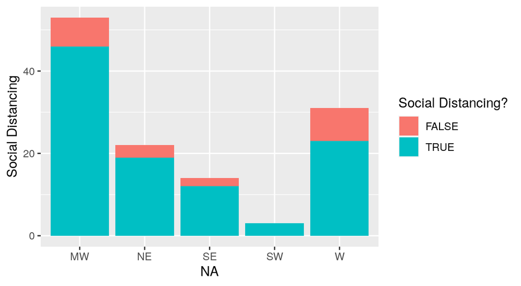

```r
elca_churches <- filter(elca_churches, Regions %in% c("MW", "NE", "SE", "W", "SW"))

gf_bar(~ Regions, fill = ~Social_Distancing, data = elca_churches) |>
  gf_labs(x = "Regions", y = 'Social Distancing')|>
  gf_theme(scale_fill_discrete('Social Distancing?'))
```